Naomi

# Naomi summary report

# Malawi - Demo Subnational HIV Estimates

### **December 2018** (report 20-12-2021)

This report summarises the **District + Metro-level** HIV indicators for **Malawi - Demo** from the Naomi model

Naomi is a statistical model that uses data from several sources, including:

National survey data:

- National household survey data on ART coverage from *DEMO2016PHIA*
- National household survey data on HIV prevalence from *DEMO2016PHIA*

Operational programme data:

- National programme data on ART coverage for *March 2016 and December 2018*
- National programme data on ANC HIV prevalence for *2016 and 2018*
- National programme data on ANC ART coverage for *2016 and 2018*

and national HIV estimates from Spectrum file *demo_mwi2019-5.pjnz* using calibration options:

- Population calibration: *None*
- New infections calibration level: *National*
- New infections calibration strata: *Sex and age <15 / 15+*
- Status known calibration level: *National*
- Status known calibration strata: *Sex and age <15 / 15+*
- ART number calibration level: *National*
- ART number calibration strata: *Sex and age <15 / 15+*
- New infections calibration level: *National*
- New infections calibration strata: *Sex and age <15 / 15+*
- Calibration method: *Logistic*

ART coverage is estimated accounting for patient mobility between neighbouring districts (for March 2016 and December 2018).

This takes into account where patients reside as opposed to the location of the clinic they attended.

Further technical information about this allocation method and the Naomi model is available at the end of this report.

### **Geographic distribution of PLHIV**

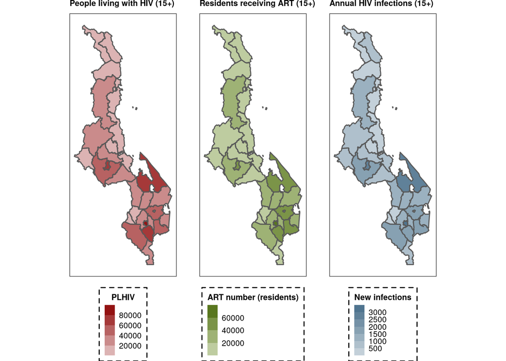

### **Geographic distribution of rates of HIV infection**

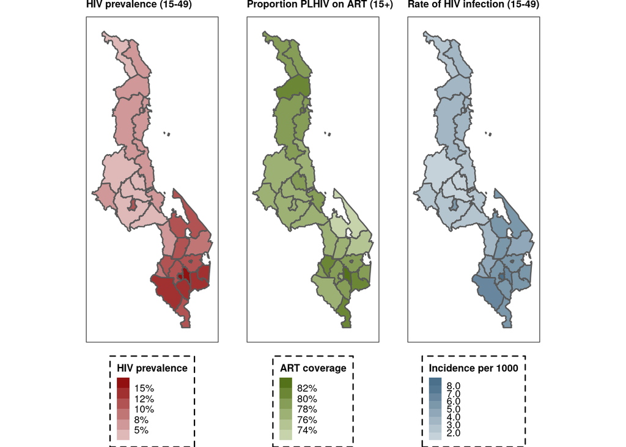

### **Distribution of HIV by age and sex**

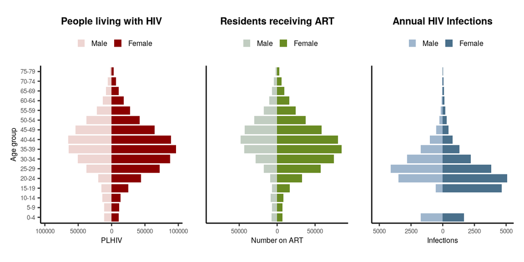

### **District + Metro-level HIV trends**

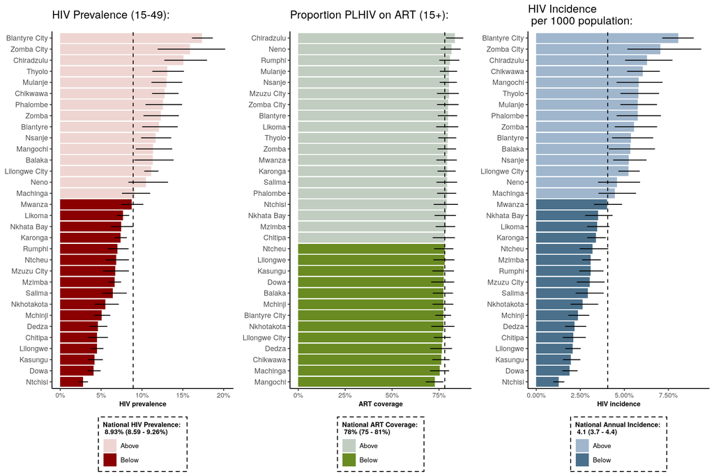

### **District + Metro-level indicators**

| *Area** | **Distribution of HIV** **PLHIV 15+** | **Distribution of HIV** **HIV prevalence 15-49** | **Annual HIV infections** **Incidence 15-49 (per 1000)** | **Annual HIV infections** **New infections 15+** | **Antiretroviral Treatment** **ART coverage 15+** | **Antiretroviral Treatment** **Number residents on ART 15+** | **Antiretroviral Treatment** **Number clients receiving ART 15+** |
| --- | --- | --- | --- | --- | --- | --- | --- |
| Country |  |  |  |  |  |  |  |
| Malawi - Demo | 985,300 (954,900-1,016,000) | 8.9% (8.6-9.3%) | 4.1 (3.7-4.4) | 33,930 (31,470-36,440) | 78.1% (75.5-80.6%) | 769,200 (766,400-772,100) | 769,200 |
| Region |  |  |  |  |  |  |  |
| Central | 276,900 (265,000-290,100) | 5.8% (5.6-6.1%) | 2.7 (2.5-2.9) | 10,120 (9,270-11,060) | 77.5% (74.4-80.6%) | 214,700 (209,400-220,500) | 214,600 |
| Northern | 98,300 (93,700-102,800) | 6.7% (6.3-7.0%) | 3.1 (2.8-3.4) | 3,440 (3,120-3,770) | 79.2% (75.7-82.6%) | 77,800 (75,600-80,200) | 76,300 |
| Southern | 610,100 (590,000-631,000) | 12.7% (12.2-13.2%) | 5.9 (5.4-6.3) | 20,360 (18,950-21,900) | 78.1% (75.4-80.7%) | 476,700 (471,600-482,200) | 478,300 |
| Zone |  |  |  |  |  |  |  |
| Central-East | 80,300 (72,800-87,700) | 4.6% (4.1-5.0%) | 2.1 (1.8-2.4) | 2,930 (2,580-3,330) | 78.1% (74.3-81.5%) | 62,700 (57,200-68,100) | 60,600 |
| Central-West | 196,600 (185,200-209,100) | 6.5% (6.1-6.9%) | 3.0 (2.7-3.3) | 7,190 (6,540-7,940) | 77.3% (74.0-80.7%) | 152,000 (144,800-159,100) | 154,000 |
| Northern | 98,300 (93,700-102,800) | 6.7% (6.3-7.0%) | 3.1 (2.8-3.4) | 3,440 (3,120-3,770) | 79.2% (75.7-82.6%) | 77,800 (75,600-80,200) | 76,300 |
| South-East | 299,900 (285,200-316,500) | 11.7% (11.1-12.4%) | 5.5 (5.0-6.1) | 10,300 (9,440-11,260) | 77.2% (74.2-80.2%) | 231,600 (222,700-240,600) | 237,500 |
| South-West | 310,200 (297,900-323,500) | 13.9% (13.3-14.5%) | 6.3 (5.8-6.8) | 10,060 (9,320-10,840) | 79.0% (76.1-81.7%) | 245,100 (237,700-252,400) | 240,800 |
| District |  |  |  |  |  |  |  |
| Balaka | 30,100 (24,100-36,700) | 11.3% (9.1-13.9%) | 5.3 (4.1-6.7) | 1,020 (810-1,250) | 77.4% (71.7-82.5%) | 23,300 (18,800-28,100) | 18,100 |
| Blantyre | 133,000 (124,200-143,100) | 15.6% (14.5-16.9%) | 7.2 (6.4-8.0) | 4,440 (4,030-4,890) | 78.1% (74.6-81.6%) | 103,800 (96,900-111,200) | 92,400 |
| Chikwawa | 44,500 (39,500-50,100) | 12.8% (11.2-14.5%) | 6.0 (5.2-7.0) | 1,520 (1,320-1,740) | 76.2% (71.4-80.7%) | 33,900 (30,100-38,300) | 28,200 |
| Chiradzulu | 35,100 (29,700-41,800) | 15.1% (12.7-18.0%) | 6.3 (5.0-7.7) | 1,000 (830-1,190) | 83.5% (78.7-87.9%) | 29,300 (24,800-34,800) | 36,600 |
| Chitipa | 6,700 (5,100-8,800) | 4.5% (3.4-5.8%) | 2.1 (1.5-2.8) | 240 (180-320) | 78.1% (71.6-83.5%) | 5,300 (4,000-6,800) | 5,900 |
| Dedza | 24,100 (19,000-30,400) | 4.6% (3.6-5.8%) | 2.2 (1.6-2.8) | 890 (680-1,150) | 76.6% (70.3-82.0%) | 18,400 (14,600-23,000) | 17,200 |
| Dowa | 20,400 (16,800-24,700) | 4.1% (3.4-4.9%) | 1.9 (1.5-2.3) | 750 (590-920) | 77.5% (70.8-83.1%) | 15,900 (12,900-19,100) | 12,300 |
| Karonga | 17,000 (15,400-18,900) | 7.4% (6.7-8.2%) | 3.4 (2.9-3.9) | 600 (510-690) | 79.4% (74.2-83.9%) | 13,500 (12,400-14,800) | 13,300 |
| Kasungu | 22,400 (18,000-27,700) | 4.2% (3.4-5.2%) | 2.0 (1.5-2.5) | 830 (640-1,050) | 77.6% (71.5-83.0%) | 17,400 (13,900-21,300) | 16,700 |
| Likoma | 800 (700-900) | 7.7% (6.9-8.4%) | 3.5 (2.9-4.2) | 30 (20-30) | 79.9% (73.5-85.2%) | 600 (600-700) | 600 |
| Lilongwe | 124,500 (116,900-133,100) | 7.3% (6.9-7.8%) | 3.4 (3.0-3.7) | 4,570 (4,090-5,060) | 77.3% (73.5-81.2%) | 96,300 (91,500-101,700) | 97,600 |
| Machinga | 38,400 (31,800-46,500) | 9.1% (7.6-11.0%) | 4.5 (3.5-5.7) | 1,410 (1,140-1,760) | 75.4% (70.2-80.4%) | 29,000 (24,300-34,400) | 26,700 |
| Mangochi | 75,400 (61,300-90,800) | 11.4% (9.2-13.7%) | 5.8 (4.6-7.2) | 2,820 (2,270-3,410) | 72.7% (67.9-77.3%) | 54,800 (45,000-65,900) | 60,400 |
| Mchinji | 19,100 (15,500-23,400) | 5.1% (4.1-6.1%) | 2.4 (1.8-3.0) | 700 (550-890) | 77.4% (71.6-82.7%) | 14,800 (12,300-17,800) | 16,300 |
| Mulanje | 55,700 (48,100-64,000) | 13.0% (11.2-14.9%) | 5.8 (4.8-6.9) | 1,760 (1,490-2,050) | 80.4% (75.5-84.7%) | 44,800 (38,500-51,700) | 50,600 |
| Mwanza | 7,300 (6,200-8,400) | 8.7% (7.5-10.2%) | 4.0 (3.3-4.9) | 260 (210-310) | 79.4% (73.6-84.5%) | 5,800 (5,000-6,600) | 5,800 |
| Mzimba | 50,000 (46,000-54,300) | 6.7% (6.1-7.3%) | 3.1 (2.7-3.5) | 1,760 (1,530-2,010) | 79.0% (74.3-83.3%) | 39,500 (36,800-42,300) | 39,100 |
| Neno | 9,000 (7,100-11,300) | 10.5% (8.3-13.2%) | 4.6 (3.5-5.9) | 290 (230-360) | 81.7% (75.9-86.6%) | 7,300 (5,800-9,100) | 7,800 |
| Nkhata Bay | 13,600 (11,200-16,300) | 7.5% (6.2-9.0%) | 3.5 (2.8-4.3) | 470 (380-580) | 78.8% (72.6-84.0%) | 10,700 (8,900-12,800) | 9,500 |
| Nkhotakota | 13,300 (10,100-17,300) | 5.5% (4.2-7.2%) | 2.6 (2.0-3.5) | 500 (370-660) | 77.3% (70.9-83.3%) | 10,300 (7,800-13,300) | 11,600 |
| Nsanje | 21,000 (17,800-24,500) | 11.6% (9.9-13.6%) | 5.2 (4.4-6.3) | 680 (570-800) | 80.3% (75.3-84.5%) | 16,800 (14,100-19,800) | 20,200 |
| Ntcheu | 28,900 (23,200-35,300) | 6.8% (5.5-8.4%) | 3.2 (2.5-4.1) | 1,020 (800-1,290) | 78.0% (72.4-82.7%) | 22,500 (18,200-27,400) | 22,900 |
| Ntchisi | 5,600 (4,500-6,800) | 2.8% (2.2-3.4%) | 1.3 (1.0-1.6) | 200 (160-250) | 79.1% (72.1-85.1%) | 4,400 (3,500-5,400) | 4,500 |
| Phalombe | 32,300 (26,700-38,200) | 12.6% (10.4-14.9%) | 5.8 (4.6-7.1) | 1,070 (870-1,290) | 79.3% (74.0-84.2%) | 25,600 (21,300-30,300) | 31,500 |
| Rumphi | 10,200 (8,500-12,100) | 7.0% (5.8-8.4%) | 3.1 (2.4-3.8) | 340 (270-420) | 80.9% (75.1-85.8%) | 8,200 (6,900-9,700) | 7,800 |
| Salima | 18,600 (14,800-23,600) | 6.4% (5.1-8.1%) | 2.9 (2.2-3.8) | 660 (510-850) | 79.4% (73.7-84.7%) | 14,800 (11,800-18,400) | 15,600 |
| Thyolo | 60,400 (52,000-69,900) | 13.1% (11.3-15.1%) | 5.8 (4.8-7.0) | 1,880 (1,580-2,200) | 79.7% (74.6-84.2%) | 48,100 (41,500-55,400) | 49,800 |
| Zomba | 68,100 (58,600-79,100) | 12.8% (11.0-14.9%) | 5.8 (4.7-6.9) | 2,210 (1,850-2,600) | 79.6% (74.8-83.8%) | 54,200 (47,000-61,700) | 50,200 |
| District + Metro |  |  |  |  |  |  |  |
| Balaka | 30,100 (24,100-36,700) | 11.3% (9.1-13.9%) | 5.3 (4.1-6.7) | 1,020 (810-1,250) | 77.4% (71.7-82.5%) | 23,300 (18,800-28,100) | 18,100 |
| Blantyre | 35,500 (29,500-42,200) | 12.1% (10.0-14.4%) | 5.4 (4.3-6.6) | 1,150 (940-1,390) | 79.9% (74.3-84.7%) | 28,400 (23,600-33,700) | 24,900 |
| Blantyre City | 97,500 (90,800-105,000) | 17.3% (16.1-18.7%) | 8.1 (7.1-8.9) | 3,290 (2,960-3,620) | 77.4% (73.0-81.4%) | 75,500 (69,700-81,500) | 67,500 |
| Chikwawa | 44,500 (39,500-50,100) | 12.8% (11.2-14.5%) | 6.0 (5.2-7.0) | 1,520 (1,320-1,740) | 76.2% (71.4-80.7%) | 33,900 (30,100-38,300) | 28,200 |
| Chiradzulu | 35,100 (29,700-41,800) | 15.1% (12.7-18.0%) | 6.3 (5.0-7.7) | 1,000 (830-1,190) | 83.5% (78.7-87.9%) | 29,300 (24,800-34,800) | 36,600 |
| Chitipa | 6,700 (5,100-8,800) | 4.5% (3.4-5.8%) | 2.1 (1.5-2.8) | 240 (180-320) | 78.1% (71.6-83.5%) | 5,300 (4,000-6,800) | 5,900 |
| Dedza | 24,100 (19,000-30,400) | 4.6% (3.6-5.8%) | 2.2 (1.6-2.8) | 890 (680-1,150) | 76.6% (70.3-82.0%) | 18,400 (14,600-23,000) | 17,200 |
| Dowa | 20,400 (16,800-24,700) | 4.1% (3.4-4.9%) | 1.9 (1.5-2.3) | 750 (590-920) | 77.5% (70.8-83.1%) | 15,900 (12,900-19,100) | 12,300 |
| Karonga | 17,000 (15,400-18,900) | 7.4% (6.7-8.2%) | 3.4 (2.9-3.9) | 600 (510-690) | 79.4% (74.2-83.9%) | 13,500 (12,400-14,800) | 13,300 |
| Kasungu | 22,400 (18,000-27,700) | 4.2% (3.4-5.2%) | 2.0 (1.5-2.5) | 830 (640-1,050) | 77.6% (71.5-83.0%) | 17,400 (13,900-21,300) | 16,700 |
| Likoma | 800 (700-900) | 7.7% (6.9-8.4%) | 3.5 (2.9-4.2) | 30 (20-30) | 79.9% (73.5-85.2%) | 600 (600-700) | 600 |
| Lilongwe | 46,800 (39,400-54,500) | 4.5% (3.8-5.3%) | 2.1 (1.6-2.5) | 1,690 (1,360-2,050) | 78.0% (72.0-83.2%) | 36,500 (31,500-42,500) | 23,100 |
| Lilongwe City | 77,700 (71,900-83,800) | 11.1% (10.3-12.0%) | 5.2 (4.7-5.9) | 2,880 (2,590-3,200) | 76.9% (72.2-81.3%) | 59,700 (54,800-64,700) | 74,500 |
| Machinga | 38,400 (31,800-46,500) | 9.1% (7.6-11.0%) | 4.5 (3.5-5.7) | 1,410 (1,140-1,760) | 75.4% (70.2-80.4%) | 29,000 (24,300-34,400) | 26,700 |
| Mangochi | 75,400 (61,300-90,800) | 11.4% (9.2-13.7%) | 5.8 (4.6-7.2) | 2,820 (2,270-3,410) | 72.7% (67.9-77.3%) | 54,800 (45,000-65,900) | 60,400 |
| Mchinji | 19,100 (15,500-23,400) | 5.1% (4.1-6.1%) | 2.4 (1.8-3.0) | 700 (550-890) | 77.4% (71.6-82.7%) | 14,800 (12,300-17,800) | 16,300 |
| Mulanje | 55,700 (48,100-64,000) | 13.0% (11.2-14.9%) | 5.8 (4.8-6.9) | 1,760 (1,490-2,050) | 80.4% (75.5-84.7%) | 44,800 (38,500-51,700) | 50,600 |
| Mwanza | 7,300 (6,200-8,400) | 8.7% (7.5-10.2%) | 4.0 (3.3-4.9) | 260 (210-310) | 79.4% (73.6-84.5%) | 5,800 (5,000-6,600) | 5,800 |
| Mzimba | 39,400 (35,300-44,100) | 6.6% (5.9-7.5%) | 3.1 (2.6-3.7) | 1,370 (1,160-1,610) | 78.6% (73.2-83.6%) | 30,900 (27,900-34,200) | 24,300 |
| Mzuzu City | 10,600 (8,300-13,200) | 6.7% (5.3-8.4%) | 3.0 (2.3-3.9) | 390 (300-490) | 80.3% (73.9-85.5%) | 8,500 (6,600-10,800) | 14,800 |
| Neno | 9,000 (7,100-11,300) | 10.5% (8.3-13.2%) | 4.6 (3.5-5.9) | 290 (230-360) | 81.7% (75.9-86.6%) | 7,300 (5,800-9,100) | 7,800 |
| Nkhata Bay | 13,600 (11,200-16,300) | 7.5% (6.2-9.0%) | 3.5 (2.8-4.3) | 470 (380-580) | 78.8% (72.6-84.0%) | 10,700 (8,900-12,800) | 9,500 |
| Nkhotakota | 13,300 (10,100-17,300) | 5.5% (4.2-7.2%) | 2.6 (2.0-3.5) | 500 (370-660) | 77.3% (70.9-83.3%) | 10,300 (7,800-13,300) | 11,600 |
| Nsanje | 21,000 (17,800-24,500) | 11.6% (9.9-13.6%) | 5.2 (4.4-6.3) | 680 (570-800) | 80.3% (75.3-84.5%) | 16,800 (14,100-19,800) | 20,200 |
| Ntcheu | 28,900 (23,200-35,300) | 6.8% (5.5-8.4%) | 3.2 (2.5-4.1) | 1,020 (800-1,290) | 78.0% (72.4-82.7%) | 22,500 (18,200-27,400) | 22,900 |
| Ntchisi | 5,600 (4,500-6,800) | 2.8% (2.2-3.4%) | 1.3 (1.0-1.6) | 200 (160-250) | 79.1% (72.1-85.1%) | 4,400 (3,500-5,400) | 4,500 |
| Phalombe | 32,300 (26,700-38,200) | 12.6% (10.4-14.9%) | 5.8 (4.6-7.1) | 1,070 (870-1,290) | 79.3% (74.0-84.2%) | 25,600 (21,300-30,300) | 31,500 |
| Rumphi | 10,200 (8,500-12,100) | 7.0% (5.8-8.4%) | 3.1 (2.4-3.8) | 340 (270-420) | 80.9% (75.1-85.8%) | 8,200 (6,900-9,700) | 7,800 |
| Salima | 18,600 (14,800-23,600) | 6.4% (5.1-8.1%) | 2.9 (2.2-3.8) | 660 (510-850) | 79.4% (73.7-84.7%) | 14,800 (11,800-18,400) | 15,600 |
| Thyolo | 60,400 (52,000-69,900) | 13.1% (11.3-15.1%) | 5.8 (4.8-7.0) | 1,880 (1,580-2,200) | 79.7% (74.6-84.2%) | 48,100 (41,500-55,400) | 49,800 |
| Zomba | 56,400 (46,900-66,700) | 12.3% (10.2-14.5%) | 5.6 (4.5-6.9) | 1,830 (1,500-2,200) | 79.5% (74.2-84.1%) | 44,900 (37,800-52,400) | 36,700 |
| Zomba City | 11,700 (8,800-14,800) | 15.9% (11.9-20.2%) | 7.0 (5.2-9.4) | 380 (290-480) | 79.9% (74.0-85.4%) | 9,300 (6,900-11,800) | 13,500 |

### Methods

[Naomi](https://github.com/mrc-ide/naomi) is a small-area estimation model for estimating HIV prevalence and PLHIV, ART coverage, and new HIV infections at district level by sex and five-year age group. The model combines district-level data about multiple outcomes from several sources in a Bayesian statistical model to produce robust indicators of subnational HIV burden.

The model produces estimates at three time points: the year of the most recent population-based survey, the current period at which the most recent ART and ANC programme data are available, and short-term one-year ahead projections for HIV programme planning purposes. Subnational population estimates by sex and age group are sourced from consensus sources in each country and adjusted to match the populations used within Spectrum by sex and age group.

*Survey data*

Cross-sectional estimates for HIV prevalence, ART coverage, and HIV incidence are produced at the mid-point of the most recent nationally representative household survey. For HIV prevalence, the model is calibrated to survey data about HIV prevalence by subnational level, sex, and five-year age group from the most recent population-based survey (for example [Population HIV Impact Assessment survey](https://phia.icap.columbia.edu/) or [Demographic and Health Survey](https://dhsprogram.com/)). Since the survey sample size in each district is relatively small, routinely reported data about HIV prevalence among pregnant women attending their first antenatal care visit, extracted from the national health information system, are used to improve estimates of the spatial pattern of HIV.

*ART Coverage*

Antiretroviral therapy coverage by district, age, and sex is estimated from household survey data about the presence of antiretroviral biomarkers in HIV-positive survey respondents. Routinely reported antiretroviral therapy coverage among pregnant women prior to first antenatal care visit is used as a covariate for the spatial pattern of antiretroviral therapy coverage. The antiretroviral therapy coverage and HIV prevalence are also calibrated so that total number on antiretroviral therapy matches that report in the Spectrum national file.

### Méthodes

[Naomi](https://github.com/mrc-ide/naomi) est un modèle d’estimation à petite échelle permettant d’estimer la prévalence du VIH et des PVVIH, la couverture ART et les nouvelles infections par le VIH au niveau du district par sexe et par groupe d’âge de cinq ans. Le modèle combine des données au niveau du district sur des résultats multiples provenant de plusieurs sources dans un modèle statistique bayésien pour produire des indicateurs robustes de la charge du VIH au niveau sous-national.

Le modèle produit des estimations à trois moments : l’année de l’enquête démographique la plus récente, la période actuelle à laquelle les données les plus récentes sur les programmes de traitement antirétroviral et de soins prénatals sont disponibles, et des projections à court terme, un an à l’avance, à des fins de planification des programmes de lutte contre le VIH. Les estimations de la population infranationale par sexe et groupe d’âge proviennent de sources consensuelles dans chaque pays et sont ajustées pour correspondre aux populations utilisées dans Spectrum par sexe et groupe d’âge.

*Données d’enquête*

Les estimations transversales de la prévalence du VIH, de la couverture du traitement antirétroviral et de l’incidence du VIH sont produites à mi-parcours de l’enquête sur les ménages la plus récente et la plus représentative au niveau national. Pour la prévalence du VIH, le modèle est calibré à partir des données d’enquête sur la prévalence du VIH par niveau sous-national, par sexe et par groupe d’âge de cinq ans de l’enquête la plus récente auprès de la population (par exemple [l’enquête d’évaluation de l’impact du VIH sur la population](https://phia.icap.columbia.edu/) ou [l’enquête démographique et sanitaire](https://dhsprogram.com/)). Étant donné que la taille de l’échantillon de l’enquête dans chaque district est relativement faible, les données régulièrement communiquées sur la prévalence du VIH parmi les femmes enceintes qui se rendent à leur première visite de soins prénatals, extraites du système national d’information sanitaire, sont utilisées pour améliorer les estimations de la répartition spatiale du VIH.

*Couverture TARV*

La couverture de la thérapie antirétrovirale par district, âge et sexe est estimée à partir des données de l’enquête sur les ménages concernant la présence de biomarqueurs antirétroviraux chez les répondants séropositifs. La couverture de la thérapie antirétrovirale signalée de façon routinière chez les femmes enceintes avant la première visite de soins prénatals est utilisée comme covariable pour le modèle spatial de la couverture de la thérapie antirétrovirale. La couverture de la thérapie antirétrovirale et la prévalence du VIH sont également calibrées de manière à ce que le nombre total de personnes sous thérapie antirétrovirale corresponde à celui déclaré dans le fichier national Spectrum.

### Métodos

[Naomi](https://github.com/mrc-ide/naomi) é um modelo de estimativa de pequena área para estimar a prevalência de VIH e o número de PVVIH, cobertura de TARV e novas infeções por VIH a nível distrital por género e grupo etário de cinco anos. O modelo combina dados de nível distrital sobre resultados múltiplos de várias fontes num modelo estatístico Bayesiano para produzir indicadores robustos da carga subnacional do VIH.

O modelo produz estimativas em três momentos: o ano do inquérito mais recente com base na população, o período atual em que os dados mais recentes dos programas de TARV e CPN estão disponíveis e projeções a curto prazo com um ano de antecedência para fins de planeamento do programa do VIH. As estimativas da população subnacional por género e grupo etário são obtidas de fontes consensuais em cada país e ajustadas para corresponder às populações utilizadas no âmbito do Spectrum por género e grupo etário.

*Dados de inquérito*

As estimativas transversais da prevalência de VIH, cobertura de TARV e incidência de VIH são produzidas no ponto médio do mais recente inquérito a agregados familiares nacionalmente representativo. Para a prevalência de VIH, o modelo é calibrado para obter dados sobre a prevalência de VIH por nível subnacional, género e grupo etário de cinco anos do inquérito mais recente com base na população (por exemplo [Population HIV Impact Assessment survey](https://phia.icap.columbia.edu/) ou [Demographic and Health Survey](https://dhsprogram.com/)). Uma vez que o tamanho da amostra do inquérito em cada distrito é relativamente pequeno, os dados rotineiramente relatados sobre a prevalência de VIH entre as mulheres grávidas que vão à sua primeira consulta pré-natal, extraídos do sistema nacional de informação de saúde, são usados para melhorar as estimativas do padrão espacial do VIH.

*Cobertura de TARV*

A cobertura da terapia antirretroviral por distrito, idade e género é estimada a partir de dados de inquéritos a agregados familiares sobre a presença de biomarcadores antirretrovirais nos inquiridos seropositivos. A cobertura da terapia antirretroviral relatada rotineiramente entre mulheres grávidas antes da primeira consulta pré-natal é utilizada como covariável para o padrão espacial de cobertura da terapia antirretroviral. A cobertura da terapia antirretroviral e a prevalência do VIH também são calibradas de modo a que o número total de pessoas em terapia antirretroviral corresponda ao que consta do ficheiro nacional Spectrum.

*ART attendance in neighbouring districts*

A challenge for estimating treatment coverage at district level is that persons may access antiretroviral therapy services in a different district than their residence, for example if facilities are closer or perceived to provide better services. The model allows for a probability that resident people living with HIV access antiretroviral therapy in a neighbouring district. The prior assumption is that the large majority of people living with HIV will access antiretroviral therapy in their district of residence, but this probability can vary based on district data about the number receiving antiretroviral therapy compared to HIV prevalence, antiretroviral therapy coverage and population.

*HIV incidence*

Direct estimates of HIV incidence are not available at subnational levels. While some recent household surveys have measured HIV incidence at the national level based on biomarker measures for recent HIV infections, too few recent infections are observed in any district to make a robust estimate. Therefore, to estimate HIV incidence at the subnational level, the HIV transmission rate from Spectrum estimates is calculated and applied to small area estimates of HIV prevalence and ART coverage in each subnational area. The sex and age distribution in each subnational area are based on HIV incidence rate ratios from Spectrum applied to the population structure in each area.

*Current estimates and one-year ahead projection*

The update estimates from the most recent household survey to the current period, the model conducts a one-step projection of the population the most recent survey to the current period. Population estimates are updated with official population estimates. The number of PLHIV is projected forward based on survival estimates by province, sex, and age group from Spectrum over the same period (which accounts for HIV disease progression and effects of ART scale up on reducing AIDS mortality). ART coverage is updated based on the number currently reported on ART from service provision data.

To extrapolate estimates a further one-year ahead for HIV planning purposes, the number of new infections and PLHIV are calculated based on the transmission rate from national or subnational Spectrum estimates. The number on ART are projected by calculating the increased in odds of ART coverage by age and sex based on ART projections input to Spectrum and applying this change in odds to each subnational area.

*Version*

The Naomi model is supported by UNAIDS and developed and maintained by the [MRC Centre for Global Infectious Disease Analysis](https://www.imperial.ac.uk/mrc-global-infectious-disease-analysis) at Imperial College London. The model receives technical guidance from the [UNAIDS Reference Group on Estimates, Modelling, and Projections](http://epidem.org/). The model was first used in 2020 and continues to be developed responsive to new data and HIV strategic information needs.

*Incidence du VIH*

Les estimations directes de l’incidence du VIH ne sont pas disponibles aux niveaux sous-nationaux. Bien que certaines enquêtes récentes auprès des ménages aient mesuré l’incidence du VIH au niveau national sur la base de mesures de biomarqueurs pour les infections récentes au VIH, trop peu d’infections récentes sont observées dans un district quelconque pour faire une estimation robuste. Par conséquent, pour estimer l’incidence du VIH au niveau sous-national, le taux de transmission du VIH à partir des estimations du Spectrum est calculé et appliqué aux estimations de la prévalence du VIH et de la couverture du TAR dans chaque zone sous-nationale. La répartition par sexe et par âge dans chaque zone infranationale est basée sur les ratios de taux d’incidence du VIH de Spectrum appliqués à la structure de la population dans chaque zone.

*Estimations actuelles et projection à un an*

Pour mettre à jour les estimations de l’enquête la plus récente auprès des ménages jusqu’à la période actuelle, le modèle effectue une projection en une étape de la population de l’enquête la plus récente jusqu’à la période actuelle. Les estimations de la population sont mises à jour avec les estimations officielles de la population. Le nombre de PLHIV est projeté vers l’avant sur la base des estimations de survie par province, sexe et groupe d’âge de Spectrum sur la même période (ce qui tient compte de la progression de la maladie du VIH et des effets de l’intensification du ART sur la réduction de la mortalité due au SIDA). La couverture du traitement antirétroviral est mise à jour sur la base du nombre de personnes actuellement déclarées sous traitement antirétroviral à partir des données sur la prestation de services.

Pour extrapoler les estimations un an à l’avance à des fins de planification de la lutte contre le VIH, le nombre de nouvelles infections et de personnes vivant avec le VIH est calculé sur la base du taux de transmission à partir des estimations nationales ou sous-nationales de Spectrum. Le nombre de personnes sous traitement antirétroviral est projeté en calculant l’augmentation des chances de bénéficier d’un traitement antirétroviral par âge et par sexe, sur la base des projections relatives au traitement antirétroviral introduites dans Spectrum, et en appliquant cette variation des chances à chaque région infranationale.

*Version*

Le modèle Naomi est soutenu par l’ONUSIDA et développé et maintenu par le [MRC Centre for Global Infectious Disease Analysis](https://www.imperial.ac.uk/mrc-global-infectious-disease-analysis) à l’Imperial College London. Le modèle reçoit des conseils techniques du [Groupe de référence de l’ONUSIDA sur les estimations, la modélisation et les projections](http://epidem.org/). Le modèle a été utilisé pour la première fois en 2020 et continue d’être développé en fonction des nouvelles données et des besoins en informations stratégiques sur le VIH.

*Incidência do VIH*

Não estão disponíveis estimativas diretas da incidência do VIH a níveis subnacionais. Embora alguns inquéritos recentes a agregados familiares tenham medido a incidência do VIH a nível nacional com base em medidas de biomarcadores para infeções recentes pelo VIH, são observadas muito poucas infeções recentes em qualquer distrito para se fazer uma estimativa robusta. Portanto, para estimar a incidência do VIH a nível subnacional, a taxa de transmissão do VIH a partir das estimativas do Spectrum é calculada e aplicada a estimativas de pequena área da prevalência do VIH e da cobertura do TARV em cada área subnacional. A distribuição por género e idade em cada área subnacional é baseada na taxa de incidência do VIH do Spectrum aplicada à estrutura da população em cada área.

*Estimativas atuais e projeção com um ano de antecedência*

Para atualizar as estimativas a partir do inquérito mais recente aos agregados familiares até ao período atual, o modelo realiza uma projeção de uma etapa da população do inquérito mais recente até ao período atual. As estimativas da população são atualizadas com estimativas oficiais da população. O número de PVVIH é projetado com base em estimativas de sobrevivência por província, género e grupo etário do Spectrum durante o mesmo período (o que explica a progressão da doença por VIH e os efeitos da escala de TARV na redução da mortalidade por SIDA). A cobertura de TARV é atualizada com base no número atualmente reportado sobre a TARV a partir de dados de prestação de serviços.

Para extrapolar as estimativas com um ano de antecedência para efeitos de planeamento da luta contra o VIH, o número de novas infeções e de PVVIH é calculado com base na taxa de transmissão das estimativas nacionais ou subnacionais do Spectrum. O número de pessoas em TARV é projetado através do cálculo do aumento da probabilidade de cobertura de TARV por idade e género com base nas projeções de TARV introduzidas no Spectrum e aplicando esta alteração às probabilidades para cada área subnacional.

*Versão*

O modelo Naomi é apoiado pela UNAIDS e desenvolvido e mantido pelo [MRC Centre for Global Infectious Disease Analysis] (https://www.imperial.ac.uk/mrc-global-infectious-disease-analysis) no Imperial College London. O modelo recebe orientação técnica do [UNAIDS Reference Group on Estimates, Modelling, and Projections](http://epidem.org/). O modelo foi usado pela primeira vez em 2020 e continua a ser desenvolvido em resposta a novos dados e necessidades de informação estratégica sobre o VIH.